# Lab 6 Key

1. Create a new R Markdown document and modify the YAML to
- Include your name
- Change the syntax highlighting to any scheme but the default. The options are `default`, `tango`, `pygments`, `kate`, `monochrome`, `espresso`, `zenburn`, `haddock`, and `textmate`. You can also use `NULL` if you want no highlighting.
- Include the option to make it easy to modify the rendering between PDF and HTML.
2. Create a code chunk that
- Does not display the code or any warnings, messages, etc. from the code, but evaluates every function/line of the code.
- Loads all the packages you decide to use for the lab
- Sets a global chunk option to make all figures 6.5" wide and the height to a value that makes sense to you.
3. Load the *ecls-k_samp.sav* dataset, and produce the plot below. Do not show the code you used (colors, themes, etc. don’t matter here).

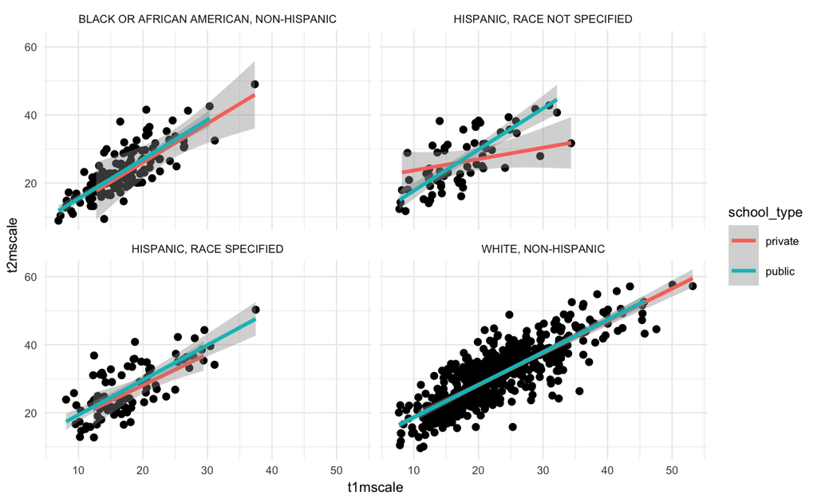

```r
library(rio)
library(here)
library(tidyverse)
library(janitor)

theme_set(theme_minimal(base_size = 8))

d <- import(here("data", "ecls-k_samp.sav"),
            setclass = "tbl_df") %>%
        characterize() %>%
        clean_names()

d %>%
  filter(ethnic == "WHITE, NON-HISPANIC" |
         ethnic == "BLACK OR AFRICAN AMERICAN, NON-HISPANIC" |
         ethnic == "HISPANIC, RACE SPECIFIED" |
         ethnic == "HISPANIC, RACE NOT SPECIFIED") %>%
ggplot(aes(t1mscale, t2mscale)) +
  geom_point() +
  geom_smooth(aes(color = school_type),
              method = "lm") +
  facet_wrap(~ethnic)
```

4. Run The following lines of code to store the mean and standard deviation of `t1mscale`. Extend this code to calculate (in the same code chunk) the mean and standard deviation of `t2mscale`. Note this code assumes you read the ecls-k dataset in as an object called `d`. You should substitute in whatever the name is for your data object.

```r
t1mean <- mean(d$t1mscale, na.rm = TRUE)
t1sd <- sd(d$t1mscale, na.rm = TRUE)
```

Using the values you calculated above, use an inline code evaluation to report the means/sds for the two time points. Also report the difference between the means (i.e., the average gain).

5. Pretend you are trying to teach somebody how to load data. Describe the process below that we’ve discussed in class, including why it helps reproducibility, and echo chunks of code as necessary without actually evaluating any of it.